# Pitcher's performance against the same team

## Looking at other statistics

Maybe ERA is too general of a measure and we need to look at some other measures. Let's look at:

- Innings pitched
- Strikeout rate (number of strikeouts/number of batters faced)
- Opponent batting average

I will present the mean difference, the confidence interval and a histogram. Note that a difference is considered statistically significant if the interval does not contain 0.

```python
def get_frame_from_id(url):
    soup = BeautifulSoup(urllib2.urlopen(url))
    table = soup.findAll("table")[1]
    rowvals = []
    game_rows = table.findAll("tr")
    for r in game_rows:
        row_entry =[]
        cols = r.findAll("td")
        for ix, val in enumerate(cols):
            if ix in [3, 6, 11, 12, 15, 16, 19, 20]:
                row_entry.append(val.text.replace(u'\xa0', ' '))
        if len(row_entry) ==8 and (len(row_entry[0])>2):
            row_entry[-1] = float((row_entry[-1]))
            row_entry[-2] = float((row_entry[-2]))
            row_entry[-3] = float((row_entry[-3]))
            row_entry[-4] = float((row_entry[-4]))
            row_entry[-5] = float((row_entry[-5]))
            row_entry[-6] = float((row_entry[-6]))
            rowvals.append(row_entry)
    frame = pd.DataFrame(rowvals)
    frame.columns = ["Data", "Opponent", "IP", "H", "BB","K", "ERA",  "BF"]
    return frame
frame = get_frame_from_id(urls[3])

def get_diff(frame, dayslimit=30, col="ERA"):
    eradiffs = []
    for ix in range(len(frame) - 1):
        thisopponent = frame.ix[ix]["Opponent"]
        today = frame.ix[ix]["Data"].split("(")[0].split("susp")[0].split(" ")[0] + " " + frame.ix[ix]["Data"].split("(")[0].split("susp")[0].split(" ")[1]# Yes, data is a typo
        todays_era = frame.ix[ix][col]
        next_ix = ix + 1
        next_opponent = frame.ix[next_ix]["Opponent"]
        next_date = frame.ix[ix + 1]["Data"].split("(")[0].split("susp")[0].split(" ")[0] + " " +frame.ix[ix + 1]["Data"].split("(")[0].split("susp")[0].split(" ")[1]
        days_ahead = date_num[next_date] - date_num[today]
        while days_ahead <dayslimit:
            if next_opponent == thisopponent:
                eradiffs.append(frame.ix[next_ix][col] - todays_era)
            next_ix += 1
            try:
                next_opponent = frame.ix[next_ix]["Opponent"]
                next_date = frame.ix[next_ix]["Data"].split("(")[0].split("susp")[0].split(" ")[0] + " " + frame.ix[next_ix]["Data"].split("(")[0].split("susp")[0].split(" ")[1]
                days_ahead = date_num[next_date] - date_num[today]
            except KeyError:
                break
    return eradiffs
```

```python
ipdiffs = []
for u in urls:
    frame = get_frame_from_id(u)
    ipdiffs.extend(get_diff(frame, dayslimit=14, col="IP"))
```

```python
np.mean(ipdiffs)
```

```
-0.11808510638297874
```

```python
sm.emplike.DescStat(np.asarray(ipdiffs)).ci_mean()
```

```
(-0.39805028558587086, 0.17838587474369597)
```

###### Innings Pitched

- Average difference = -.11
- Confidence Interval = (-.39, .17)

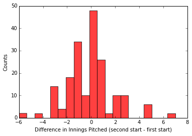

```python
fig, ax = plt.subplots()
ax.set_xlabel("Difference in Innings Pitched (second start - first start)")
ax.set_ylabel("Counts")
ax.hist(ipdiffs, color='red', alpha=.75, bins=20);
```

###### Strikeout and strikeout rate

```python
sodiff = []
sorate_diffs = []
for u in urls:
    frame = get_frame_from_id(u)
    frame["sorate"] = frame["K"]/frame["BF"]
    sorate_diffs.extend(get_diff(frame, dayslimit=14, col="sorate"))
    sodiff.extend(get_diff(frame, dayslimit=14, col="K"))
```

```python
#np.mean(sodiff)
#sm.emplike.DescStat(np.asarray(sodiff)).ci_mean()
```

- Mean difference is strikeouts is -.02
- confidence interval is [-.42, .36 ]

```python
fig, ax = plt.subplots()
ax.set_xlabel("Difference in Strike outs (second start - first start)")
ax.set_ylabel("Counts")
ax.hist(sodiff, color='red', alpha=.75, bins=20);
```

[output not shown]

```python
print np.mean(sorate_diffs)
sm.emplike.DescStat(np.asarray(sorate_diffs)).ci_mean()
```

[output not shown]

- Mean difference in strikeout rate = .008
- Confidence interval = [-.01, .03]

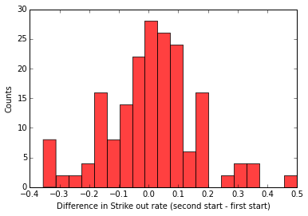

```python
fig, ax = plt.subplots()
ax.set_xlabel("Difference in Strike out rate (second start - first start)")
ax.set_ylabel("Counts")
ax.hist(sorate_diffs, color='red', alpha=.75, bins=20);
```

###### Opponent Batting Average

```python
ba_diffs = []
sodiff = []
sorate_diffs = []
for u in urls:
    frame = get_frame_from_id(u)
    frame["BA"] = frame["H"] / (frame["BF"] - frame["BB"])
    ba_diffs.extend(get_diff(frame, dayslimit=14, col="BA"))
```

- The mean difference in batting average is .030 (that's thirty points)
- The confidence interval is [0, .06]

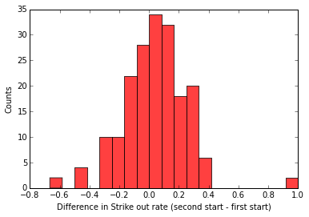

```python
fig, ax = plt.subplots()
ax.set_xlabel("Difference in Strike out rate (second start - first start)")
ax.set_ylabel("Counts")
ax.hist(ba_diffs, color='red', alpha=.75, bins=20);
```

# Summary

The interesting question now is why doesn't that increase in batting average induce a higher pitcher ERA? From a fantasy perspective, is the increase in 30 points a significant enough factor when choosing which pitchers to start for the week?